# Tugas Pertemuan 5 MPDW

# **Tanpa Partisi (Data Penuh)**

### Impor Data

```r
library(rio)
datachicken <- import("https://raw.githubusercontent.com/Anissls333/mpdw/main/pertemuan%205/data.csv")
```

### Library yang digunakan

```r
library(ggplot2)
library(tsibble)
library(tseries)
library(MASS)
```

### Mengubah tipe data Price menjadi time series

Bertujuan agar data terbaca sebagai data deret waktu

```r
datachicken$Price <- ts(datachicken$Price)
View(datachicken)
datachicken.ts <- datachicken$Price
```

### Plot *Time Series*

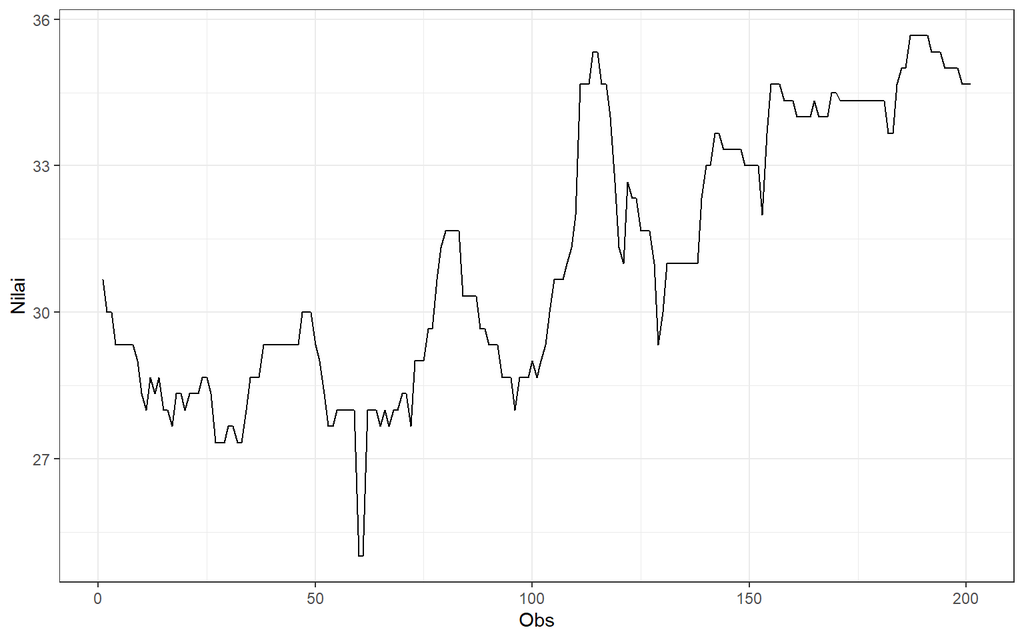

```r
plot<- datachicken |>
  ggplot(aes(x = Periode, y = Price)) + geom_line() + theme_bw() +
  xlab("Obs") + ylab("Nilai")
plot
```

Plot deret waktu di atas menunjukkan bahwa data tidak stasioner dalam rataan, ditandai dengan data yang tidak menyebar di suatu nilai tengah tertentu dan tidak stasioner dalam ragam, ditandai dengan lebar pita yang cenderung berbeda.

### Plot ACF

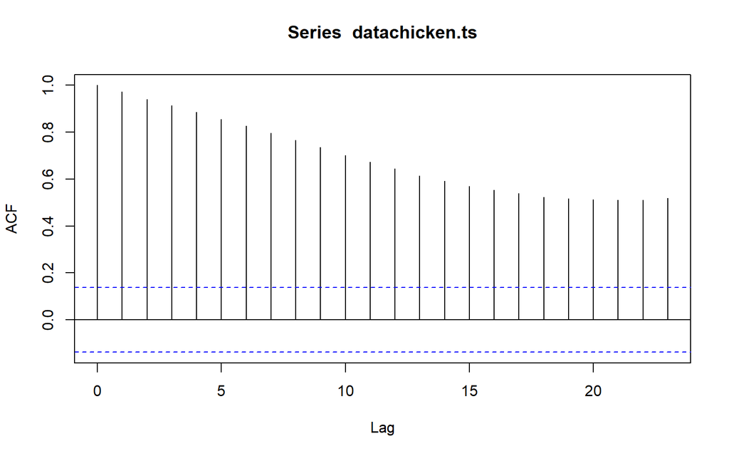

```r
acf(datachicken.ts)
```

Berdasarkan plot ACF, terlihat bahwa plot ACF pada data tersebut cenderung *tails off slowly* yang menandakan data tidak stasioner dalam rataan.

### Uji ADF

```r
tseries::adf.test(datachicken.ts)
```

```
##
##  Augmented Dickey-Fuller Test
##
## data:  datachicken.ts
## Dickey-Fuller = -3.795, Lag order = 5, p-value = 0.02047
## alternative hypothesis: stationary
```

$H_0$ : Data tidak stasioner dalam rataan

$H_1$ : Data stasioner dalam rataan

Berdasarkan uji ADF tersebut, didapat *p-value* sebesar 0.02047 yang lebih kecil dari taraf nyata 5% sehingga tolak $H_0$ dan menandakan bahwa data stasioner dalam rataan. Hal ini tidak sesuai dengan hasil eksplorasi menggunakan plot time series dan plot ACF. Setelah dicoba-coba dengan mengganti nilai k (dinaikkan nilai k nya) hasil *p-value* tetap lebih kecil dari taraf nyata 5%. Sehingga kesimpulannya tidak benar.

### Plot Box-Cox

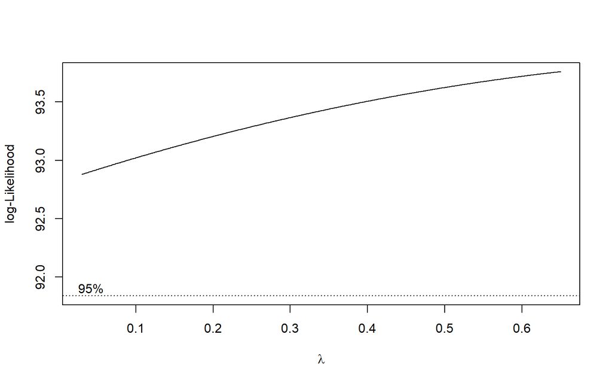

```r
n = length(datachicken.ts)
index <- seq(1:n)
bc = boxcox(datachicken.ts~index, lambda = seq(0.03,0.65,by=0.001))
```

```r
#Nilai Rounded Lambda
lambda <- bc$x[which.max(bc$y)]
lambda
```

```
## [1] 0.65
```

```r
#SK
bc$x[bc$y > max(bc$y) - 1/2 * qchisq(.95,1)]
```

```
##   [1] 0.030 0.031 0.032 0.033 0.034 0.035 0.036 0.037 0.038 0.039 0.040 0.041
##  [13] 0.042 0.043 0.044 0.045 0.046 0.047 0.048 0.049 0.050 0.051 0.052 0.053
##  [25] 0.054 0.055 0.056 0.057 0.058 0.059 0.060 0.061 0.062 0.063 0.064 0.065
##  [37] 0.066 0.067 0.068 0.069 0.070 0.071 0.072 0.073 0.074 0.075 0.076 0.077
##  [49] 0.078 0.079 0.080 0.081 0.082 0.083 0.084 0.085 0.086 0.087 0.088 0.089
##  [61] 0.090 0.091 0.092 0.093 0.094 0.095 0.096 0.097 0.098 0.099 0.100 0.101
##  [73] 0.102 0.103 0.104 0.105 0.106 0.107 0.108 0.109 0.110 0.111 0.112 0.113
##  [85] 0.114 0.115 0.116 0.117 0.118 0.119 0.120 0.121 0.122 0.123 0.124 0.125
##  [97] 0.126 0.127 0.128 0.129 0.130 0.131 0.132 0.133 0.134 0.135 0.136 0.137
## [109] 0.138 0.139 0.140 0.141 0.142 0.143 0.144 0.145 0.146 0.147 0.148 0.149
## [121] 0.150 0.151 0.152 0.153 0.154 0.155 0.156 0.157 0.158 0.159 0.160 0.161
## [133] 0.162 0.163 0.164 0.165 0.166 0.167 0.168 0.169 0.170 0.171 0.172 0.173
## [145] 0.174 0.175 0.176 0.177 0.178 0.179 0.180 0.181 0.182 0.183 0.184 0.185
## [157] 0.186 0.187 0.188 0.189 0.190 0.191 0.192 0.193 0.194 0.195 0.196 0.197
## [169] 0.198 0.199 0.200 0.201 0.202 0.203 0.204 0.205 0.206 0.207 0.208 0.209
```

[output cut: 37 more lines]

Gambar di atas menunjukkan nilai *rounded value* ($\lambda$) optimum sebesar **0.65** dan pada selang kepercayaan 95% nilai memiliki batas bawah **0.03** dan batas atas **0.65**. Selang tersebut tidak memuat nilai satu sehingga dapat dikatakan bahwa data chicken price tidak stasioner dalam ragam.

# **Partisi Data**

## **Bagian 1**

```r
dt_stas1 <- datachicken.ts[1:76] |> ts()
mean(dt_stas1)
```

```
## [1] 28.46924
```

```r
var(dt_stas1)
```

```
## [1] 0.9367566
```

### Plot Time Series

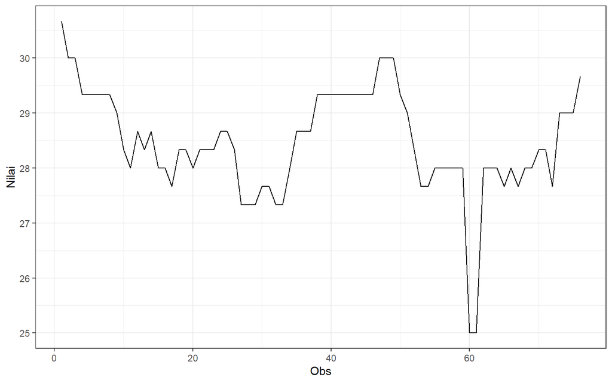

```r
dt_stas1 |> as_tsibble() |>
  ggplot(aes(x = index , y = value)) +
  geom_line() + theme_bw() +
  xlab("Obs") + ylab("Nilai")
```

Plot deret waktu di atas menunjukkan bahwa data chicken price partisi pertama tidak stasioner dalam rataan, ditandai dengan data yang tidak menyebar di suatu nilai tengah tertentu dan tidak stasioner dalam ragam, ditandai dengan lebar pita yang cenderung berbeda.

### Plot ACF

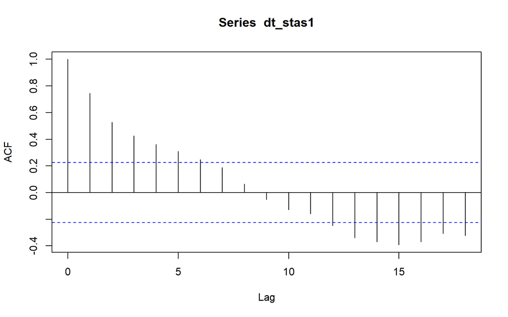

```r
acf(dt_stas1)
```

Berdasarkan plot ACF, terlihat bahwa plot ACF pada data tersebut cenderung *tails off slowly* dan membentuk gelombang sinus yang menandakan bahwa data chicken price partisi pertama tidak stasioner dalam rataan.

### Uji ADF

```r
tseries::adf.test(dt_stas1)
```

```
##
##  Augmented Dickey-Fuller Test
##
## data:  dt_stas1
## Dickey-Fuller = -2.0619, Lag order = 4, p-value = 0.5503
## alternative hypothesis: stationary
```

$H_0$ : Data tidak stasioner dalam rataan

$H_1$ : Data stasioner dalam rataan

Berdasarkan uji ADF tersebut, didapat *p-value* sebesar 0.5503 yang lebih besar dari taraf nyata 5% sehingga tak tolak $H_0$ dan menandakan bahwa data chicken price partisi pertama tidak stasioner dalam rataan. Hal ini sesuai dengan hasil eksplorasi menggunakan plot time series dan plot ACF.

### Plot Boxcox

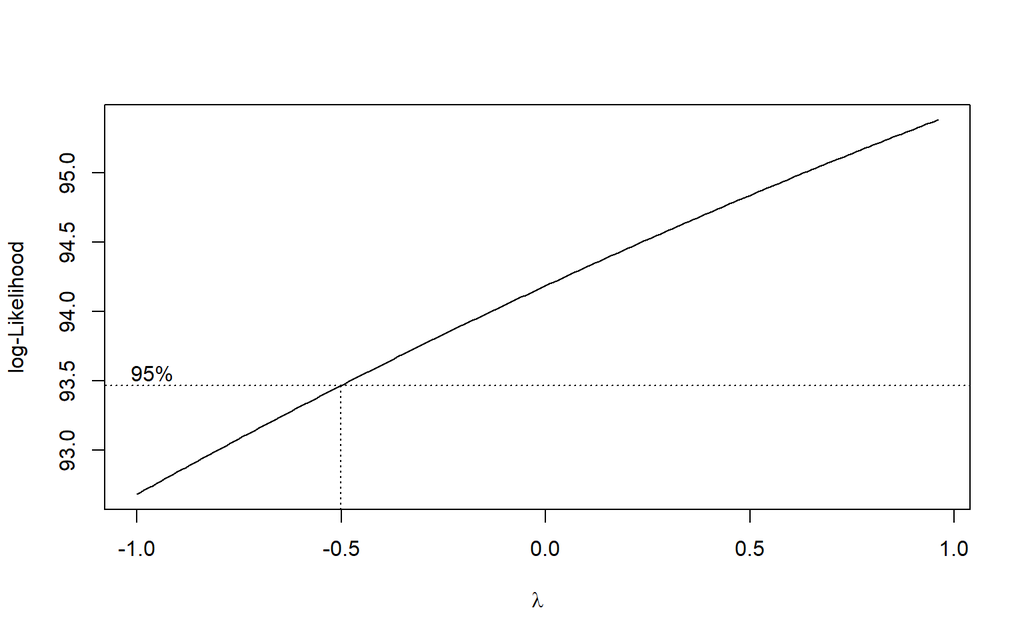

```r
index <- seq(1:76)
bc = boxcox(dt_stas1~index, lambda = seq(-1,0.96,by=0.01))
```

```r
#Nilai Rounded Lambda
lambda <- bc$x[which.max(bc$y)]
lambda
```

```
## [1] 0.96
```

```r
#SK
bc$x[bc$y > max(bc$y) - 1/2 * qchisq(.95,1)]
```

```
##   [1] -0.50 -0.49 -0.48 -0.47 -0.46 -0.45 -0.44 -0.43 -0.42 -0.41 -0.40 -0.39
##  [13] -0.38 -0.37 -0.36 -0.35 -0.34 -0.33 -0.32 -0.31 -0.30 -0.29 -0.28 -0.27
##  [25] -0.26 -0.25 -0.24 -0.23 -0.22 -0.21 -0.20 -0.19 -0.18 -0.17 -0.16 -0.15
##  [37] -0.14 -0.13 -0.12 -0.11 -0.10 -0.09 -0.08 -0.07 -0.06 -0.05 -0.04 -0.03
##  [49] -0.02 -0.01  0.00  0.01  0.02  0.03  0.04  0.05  0.06  0.07  0.08  0.09
##  [61]  0.10  0.11  0.12  0.13  0.14  0.15  0.16  0.17  0.18  0.19  0.20  0.21
##  [73]  0.22  0.23  0.24  0.25  0.26  0.27  0.28  0.29  0.30  0.31  0.32  0.33
##  [85]  0.34  0.35  0.36  0.37  0.38  0.39  0.40  0.41  0.42  0.43  0.44  0.45
##  [97]  0.46  0.47  0.48  0.49  0.50  0.51  0.52  0.53  0.54  0.55  0.56  0.57
## [109]  0.58  0.59  0.60  0.61  0.62  0.63  0.64  0.65  0.66  0.67  0.68  0.69
## [121]  0.70  0.71  0.72  0.73  0.74  0.75  0.76  0.77  0.78  0.79  0.80  0.81
## [133]  0.82  0.83  0.84  0.85  0.86  0.87  0.88  0.89  0.90  0.91  0.92  0.93
## [145]  0.94  0.95  0.96
```

Gambar di atas menunjukkan nilai *rounded value* ($\lambda$) optimum sebesar **0.96** dan pada selang kepercayaan 95% nilai memiliki batas bawah **-0.50** dan batas atas **0.96**. Selang tersebut tidak memuat nilai satu sehingga dapat dikatakan bahwa data chicken price partisi pertama tidak stasioner dalam ragam.

## **Bagian 2**

```r
dt_stas2 <- datachicken.ts[1:167] |> ts()
mean(dt_stas2)
```

```
## [1] 30.31138
```

```r
var(dt_stas2)
```

```
## [1] 5.408637
```

### Plot Time Series

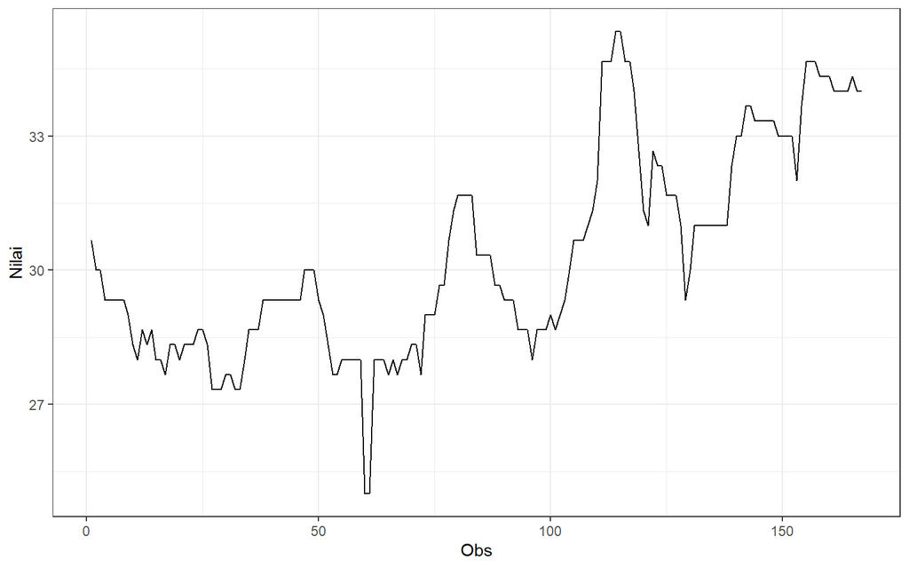

```r
dt_stas2 |> as_tsibble() |>
  ggplot(aes(x = index, y = value)) +
  geom_line() + theme_bw() +
  xlab("Obs") + ylab("Nilai")
```

Plot deret waktu di atas menunjukkan bahwa data chicken price partisi kedua tidak stasioner dalam rataan, ditandai dengan data yang tidak menyebar di suatu nilai tengah tertentu dan tidak stasioner dalam ragam, ditandai dengan lebar pita yang cenderung berbeda.

### Plot ACF

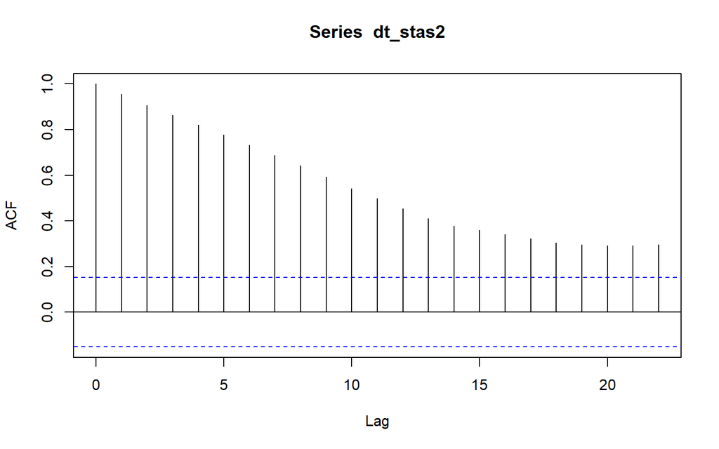

```r
acf(dt_stas2)
```

Berdasarkan plot ACF, terlihat bahwa plot ACF pada data tersebut cenderung *tails off slowly* yang menandakan data chicken price partisi kedua tidak stasioner dalam rataan.

### Uji ADF

```r
adf.test(dt_stas2)
```

```
##
##  Augmented Dickey-Fuller Test
##
## data:  dt_stas2
## Dickey-Fuller = -3.3985, Lag order = 5, p-value = 0.05712
## alternative hypothesis: stationary
```

$H_0$ : Data tidak stasioner dalam rataan

$H_1$ : Data stasioner dalam rataan

Berdasarkan uji ADF tersebut, didapat *p-value* sebesar 0.05712 yang lebih besar dari taraf nyata 5% sehingga tak tolak $H_0$ dan menandakan bahwa data chicken price partisi kedua tidak stasioner dalam rataan. Hal ini sesuai dengan hasil eksplorasi menggunakan plot time series dan plot ACF.

### Plot Boxcox

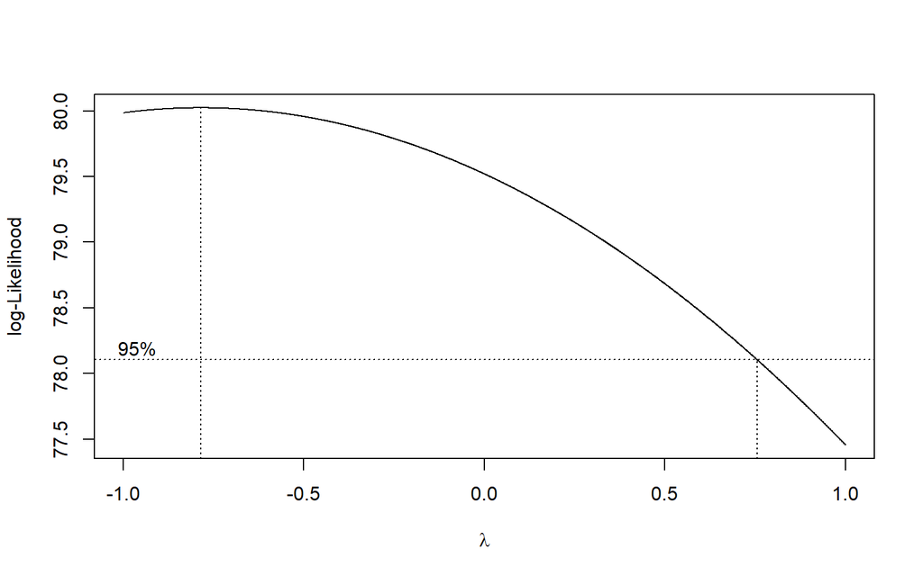

```r
index <- seq(1:167)
bc = boxcox(dt_stas2~index, lambda = seq(-1,1,by=0.001))
```

```r
#Nilai Rounded Lambda
lambda <- bc$x[which.max(bc$y)]
lambda
```

```
## [1] -0.785
```

```r
#SK
bc$x[bc$y > max(bc$y) - 1/2 * qchisq(.95,1)]
```

```
##    [1] -1.000 -0.999 -0.998 -0.997 -0.996 -0.995 -0.994 -0.993 -0.992 -0.991
##   [11] -0.990 -0.989 -0.988 -0.987 -0.986 -0.985 -0.984 -0.983 -0.982 -0.981
##   [21] -0.980 -0.979 -0.978 -0.977 -0.976 -0.975 -0.974 -0.973 -0.972 -0.971
##   [31] -0.970 -0.969 -0.968 -0.967 -0.966 -0.965 -0.964 -0.963 -0.962 -0.961
##   [41] -0.960 -0.959 -0.958 -0.957 -0.956 -0.955 -0.954 -0.953 -0.952 -0.951
##   [51] -0.950 -0.949 -0.948 -0.947 -0.946 -0.945 -0.944 -0.943 -0.942 -0.941
##   [61] -0.940 -0.939 -0.938 -0.937 -0.936 -0.935 -0.934 -0.933 -0.932 -0.931
##   [71] -0.930 -0.929 -0.928 -0.927 -0.926 -0.925 -0.924 -0.923 -0.922 -0.921
##   [81] -0.920 -0.919 -0.918 -0.917 -0.916 -0.915 -0.914 -0.913 -0.912 -0.911
##   [91] -0.910 -0.909 -0.908 -0.907 -0.906 -0.905 -0.904 -0.903 -0.902 -0.901
##  [101] -0.900 -0.899 -0.898 -0.897 -0.896 -0.895 -0.894 -0.893 -0.892 -0.891
##  [111] -0.890 -0.889 -0.888 -0.887 -0.886 -0.885 -0.884 -0.883 -0.882 -0.881
##  [121] -0.880 -0.879 -0.878 -0.877 -0.876 -0.875 -0.874 -0.873 -0.872 -0.871
##  [131] -0.870 -0.869 -0.868 -0.867 -0.866 -0.865 -0.864 -0.863 -0.862 -0.861
##  [141] -0.860 -0.859 -0.858 -0.857 -0.856 -0.855 -0.854 -0.853 -0.852 -0.851
```

[output cut: 161 more lines]

Gambar di atas menunjukkan nilai *rounded value* ($\lambda$) optimum sebesar **-0.785** dan pada selang kepercayaan 95% nilai memiliki batas bawah **-1.00** dan batas atas **0.755**. Selang tersebut tidak memuat nilai satu sehingga dapat dikatakan bahwa data chicken price partisi kedua tidak stasioner dalam ragam.